# MMLOS usage

Nick Fournier, PhD

9/15/2020

### R Markdown

This is a vignette going through a simple example use of **MMLOS**, the Multi-Modal Level of Service calculator from the Highway Capacity Manual in *R*. In this vignette we will go over basic usage of MMLOS for calculating the LOS of links, intersections, and segments for bicycles and pedestrians (automobiles and transit to be implemented in future versions). This includes loading the link and intersection data from CSV and the proper data format of the CSV data. We will also do a bit of plotting the results, and comparing the results from the existing HCM methodology to our proposed revisions.

### Data formatting

Link data format:

| Variable | Description |
| --- | --- |
| link_id | Link Identification, name and direction or number |
| link_dir | Direction |
| boundary_id | Corresponding segment boundary intersection |
| LL | Link length (ft) |
| N_aps | Number of access point approaches on right side of subject direction |
| P_HV | Heavy vehicle percentage |
| S_lim | Posted speed limit (mi/hr) |
| S_f | Free-flow speed (mi/hr). If not measured, leave blank, it will be calculated using HCM methodology. |
| S_85mj | 85th Percentile speed along midsegment. If unavailable, leave blank. Defaults to free-flow speed. |
| S_pf | Pedestrian walking speeed (ft/s) |
| S_b | Bicycle running speed (mph) |
| N_mth | Number of midsegment through lanes in the subject direction of travel |
| W_T | Total walkway width |
| W_bl | Bicycle lane width (ft) (Entire entire width if shared with peds) |
| W_swbuf | Buffer width from sidewalk to street (ft) |
| W_blbuf | Buffer width from bike lane to street (ft) |
| W_os | Paved outside shoulder width [includes parking] (ft) |
| W_ol | Outside travel lane (closest to sidewalk) width (ft) |
| w_oi | Fixed object width on inside of sidewalk |
| w_oo | Fixed object width on outside of sidewalk |
| pwindow | Portion of sidewalk length adjacent to window display |
| pbuilding | Portion of sidewalk adjacent to building face |
| pfence | Portion of sidewalk adjacent to fence or low wall |
| p_pk | Proportion of on-street parking occupied |
| p_g | Approach grade |
| P_c | Pavement condition rating (0 to 5) |
| p_mx | Proportion of midblock pedestrian demand (default = 0.35) |
| H_blbuf | Height of barrier between street and bike lane |
| H_swbuf | Height of barrier between street and sidewalk |
| protected | Is the bike lane protected by parking? |
| div | Percent of street divided by median (decimal). |
| p_strp | Are parking spaces striped? |
| curb | Curb is present? |
| sharedbl | Shared bike and pedestrian path? (bikelane and sidewalk) |
| n_bus | Number of local buses on street segment per hour (bus/h) |
| n_xbus | Number of express buses stopping in segment per hour (bus/h) |
| p_ot | Proportion of transit vehicles arriving on-time, within the threshold late time. Default = 0.75 |
| t_late | Threshold late time. Deault = 5 min |
| F_l | Average passenger load factor (p/seat) |
| L_pt | Average passenger trip length (mi) |
| pop | Is the segment in the CBD of a metro area of 5 million or more? |
| p_sh | Percent stops in segment with a shelter |
| p_be | Percent stops in segment with a bench |
| bus | Does the link direction has bus service? |
| nearside | Is the bus stop on the near-side of the intersection? |

Intersection data format:

| Variable | Description |
| --- | --- |
| int_id | Intersection identification, name and direction or number |
| app_dir | Intersection approach direction |
| traf_dir | Traffic direction |
| N_dc | Number of traffic lanes crossed when traversing the crosswalk |
| N_th | Number of through lanes in the midsegment (both directions) |
| v_rt | Right-turn demand flow rate (veh/h) |
| v_lt | Left-turn demand flow rate (veh/h) |
| v_th | Through movement demand flow rate (veh/h) |
| v_rtor | Right-turn-on-red flow rate (veh/h) |
| v_ltperm | Permited left-turn demand flow rate (veh/h) |
| v_p | Pedestrian demand flow rate (ped/h) |
| v_bth | Bicycle flow rate |
| v_bl | Bicycle left turn volume (veh/hr) |
| v_br | Bicycle right turn volume (veh/hr) |
| p_bl2 | Proportion of two-stage left turns for bicycles (decimal) |
| N_rtcid | Number of right-turn channelizing islands along the crosswalk |
| g | Green time (s) |
| gped | Green time for pedestrians (s) |
| l | Clearance time |
| C | Cycle length (s) |
| Walkmi | Pedestrian walk setting for the phase serving the minor street through movement (s) |
| W_c | Crosswalk width (ft) |
| W_cd | Curb-to-curb width of the street being crossed i.e., crosswalk length (ft) |
| M_yp | Motorist pedestrian yield rate (decimal) |
| M_yb | Motorist bicycle yield rate (decimal) |
| S_p | Pedestrian crossing speed (ft/s) |
| S_b | Bicycle crossing speed (ft/s) |
| t_sb | Bicycle start-up and clearance time (s) |
| t_sp | Pedestrian start-up and clearance time (s) |
| control | Traffic control? |

### General Usage

First install, if you haven’t already, and load the package. MMLOS includes the dependency [data.table"](https://cran.r-project.org/web/packages/data.table/vignettes/datatable-intro.html), which provides efficient data handling functions coded in C++, offering a much faster alternative to base-*R* data frames.

```r
# #Install the MMLOS package (commented out to avoid errors)
# library(devtools)
# install_github("nick-fournier/MMLOS")

#Activate the installed package.
library(MMLOS)
```

After roadway data has been properly formatted into the **link** and **intersection** CSV files, they can be imported to *R*. The **dirs** parameter is a string vector with the two file locations. If left empty, a GUI prompt will pop up. Otherwise if one of the templates “berkeley” or “pasadena” are entered, it’ll just use the template files I have provided. For now we’ll just use the template data.

```r
dat <- MMLOSload("berkeley")
```

We can take a peak at this. Note the NAs in this example are because some intersections are only three-ways, so one approach is missing.

```r
lapply(MMLOSload("berkeley"),function(x) head(x,8))
```

```
## $intersections
##      int_id app_dir traf_dir N_dc N_th v_rt v_lt v_th v_rtor v_ltperm v_p v_bth
## 1: Shattuck       S       NB    5    4   34   10  291     17      5.0  70     0
## 2: Shattuck       N       SB    5    4   48  132  682     24     66.0 120    26
## 3: Shattuck       E       WB    4    2   36   20  280     18     10.0 160    40
## 4: Shattuck       W       EB    4    2   88   64  187     44     32.0 120    15
## 5:   Walnut       S       NB   NA   NA   NA   NA   NA     NA       NA  NA    NA
## 6:   Walnut       N       SB    2    2   36    9    0     18      4.5 116     0
## 7:   Walnut       E       WB    3    2    0   15  315      0      7.5   0    72
## 8:   Walnut       W       EB    3    2   10    0  212      5      0.0   0     8
##    v_bl v_br p_bl2 N_rtcid    g gped   l  C Walkmi W_c W_cd M_yp M_yb S_p S_b
## 1:    3    2   0.5       0 31.7 31.7 3.3 90   31.7  12   52  0.5  0.1 3.5  10
## 2:    3    0   0.5       0 31.7 31.7 3.3 90   31.7  12   52  0.5  0.1 3.5  10
## 3:   62   36   0.5       0 31.1 31.1 3.9 90   31.1  12   64  0.5  0.1 3.5  10
## 4:    8    0   0.5       0 31.1 31.1 3.9 90   31.1  12   64  0.5  0.1 3.5  10
```

[output cut: 51 more lines]

Now we can calculate the LOS. The “existing” result uses the current HCM methodology, and the “revised” result uses the proposed revisions. Let’s display what the results look like for the existing methodology. The results have a list of data tables for each mode.

```r
existing <- MMLOScalc(dat, revs = F)
revised <- MMLOScalc(dat, revs = T)

#Display results
print(existing)
```

```
## $bike
##               segment_id direction    mode   I_link    I_int    I_seg link_LOS
##  1:      Shattuck-Walnut        EB bicycle 3.669667 1.562875 3.489644        D
##  2:      Shattuck-Walnut        WB bicycle 3.443762 1.371850 3.401002        C
##  3:        Walnut-Oxford        EB bicycle 3.955971 0.670750 3.482955        D
##  4:        Walnut-Oxford        WB bicycle 3.055508 2.030425 3.422672        C
##  5:        Oxford-Spruce        EB bicycle 3.826616 1.596175 3.516534        D
##  6:        Oxford-Spruce        WB bicycle 3.724147 1.453900 3.445863        D
##  7: Spruce-Arch/Le Conte        EB bicycle 3.201051 0.773050 3.362168        C
##  8: Spruce-Arch/Le Conte        WB bicycle 3.294876 2.149450 3.471562        C
##  9: Arch/Le Conte-Euclid        EB bicycle 4.071955 0.703750 3.523747        D
## 10: Arch/Le Conte-Euclid        WB bicycle 4.441266 2.497700 3.694302        E
## 11:        Euclid-Le Roy        EB bicycle 3.725146 1.729550 3.508043        D
## 12:        Euclid-Le Roy        WB bicycle 4.080222 2.431625 3.627986        D
## 13:       Le Roy-La Loma        EB bicycle 3.416482 1.717175 3.457894        C
```

[output cut: 51 more lines]

The results can be exported to a CSV by using the command:

```r
MMLOSsave(existing, "./some output folder/existing LOS.csv")
MMLOSsave(revised, "./some output folder/revised LOS.csv")
```

## Differences between existing and revised HCM results

Alright now lets compare the results a bit for bikes to see how the revised methodology alters the outcome. The numeric scores then translate to letter grades, let’s see how they compare. First we subset the letter grades in each result and combine them into a table. Although the row order is already sorted in each table, I like to use the merge command to ensure that nothing becomes mixed up. I then add the suffixed of " Existing" and " Revised" to distinguish the columns from each other.

```r
# Add a new column with the methodology version
# This is data.table syntax for assigning to a column.
existing[['bike']][ , method := "Existing"]
revised[['bike']][ , method := "Revised"]

# Combine the data tables horizontally (add columns).
# We select only the letter grade columns
bike.grade <- merge(existing[['bike']][ , .(segment_id,direction, link_LOS, int_LOS, seg_LOS)],
      revised[['bike']][ , .(segment_id,direction, link_LOS, int_LOS, seg_LOS)],
      by = c("segment_id","direction"),
      suffixes = c(" Existing"," Revised"))

#Sort columns to my liking
bike.grade <- bike.grade[ , c(1:2,order(colnames(bike.grade)[-(1:2)])+2), with = F]
```

| segment_id | direction | int_LOS Existing | int_LOS Revised | link_LOS Existing | link_LOS Revised | seg_LOS Existing | seg_LOS Revised |
| --- | --- | --- | --- | --- | --- | --- | --- |
| Arch/Le Conte-Euclid | EB | A | A | D | D | D | D |
| Arch/Le Conte-Euclid | WB | B | C | E | E | D | D |
| Euclid-Le Roy | EB | A | B | D | D | D | D |
| Euclid-Le Roy | WB | B | C | D | D | D | D |
| Le Roy-La Loma | EB | A | B | C | C | C | D |
| Le Roy-La Loma | WB | B | D | D | D | D | D |
| Oxford-Spruce | EB | A | B | D | D | D | D |
| Oxford-Spruce | WB | A | B | D | D | C | D |
| Shattuck-Walnut | EB | A | B | D | D | C | D |
| Shattuck-Walnut | WB | A | B | C | A | C | C |
| Spruce-Arch/Le Conte | EB | A | A | C | A | C | C |
| Spruce-Arch/Le Conte | WB | B | C | C | C | C | D |
| Walnut-Oxford | EB | A | A | D | D | C | D |
| Walnut-Oxford | WB | B | C | C | A | C | C |

In general we can see that the revised version tends to have higher (worse) LOS score at intersections. This is because it now accounts for additional bicycle delay. We can also see that a few links (i.e., westbound Shattuck-Walnut, eastbound Spruce-Arch/Le Conte, and westbound Walnut-Oxford) had a reduced LOS score. This reduced LOS score is due to the revised LOS methodology accounting for separated bike lanes, specifically parking protected lanes that provide vertical separation. It is hard to tell exactly what’s going on through, because the magnitude of score differences cannot be seen after the score is converted into a discrete letter grade. Let’s see what the numbers look like visually. Basically what I am doing here is combining the two results into a single data table again, but stacked vertically (long format), and adding some row ID’s to keep it organized.

```r
# Add row number, help us to sort it later
existing[['bike']]$rn <- 1:nrow(existing[['bike']])
revised[['bike']]$rn <- 1:nrow(revised[['bike']])

# Combine the data tables vertically (stacking rows). Vertical format makes plotting easier
bike.scores <- rbind(existing[['bike']], revised[['bike']])

# Let's create a new unique ID column that contains the segment ID, direction, and methodology version
bike.scores[ , id := paste(segment_id, direction, method)]

library(data.table)
#Re-shape the data from wide into long format. This is for the numeric scores
bike.scores <- melt(bike.scores[ , .(id, rn, method, I_int, I_link, I_seg)], id.vars = c("id","rn","method"))

#Sort data
bike.scores <- bike.scores[order(rn), ]

#Labels
bike.scores[variable == "I_int", variable := "Intersection"]
bike.scores[variable == "I_link", variable := "Link"]
bike.scores[variable == "I_seg", variable := "Segment"]

#Reshape for another plot
bike.scoresxy <- dcast(bike.scores, rn+variable~method, value.var = "value")
```

Long format is generally easier to plot with because you are storing all the values in one column, which are then categorized by a “variable” column. To show what I mean, let’s print the table out.

```r
head(bike.scores)
```

```
##                             id rn   method     variable    value
## 1: Shattuck-Walnut EB Existing  1 Existing Intersection 1.562875
## 2:  Shattuck-Walnut EB Revised  1  Revised Intersection 2.432382
## 3: Shattuck-Walnut EB Existing  1 Existing         Link 3.669667
## 4:  Shattuck-Walnut EB Revised  1  Revised         Link 3.669667
## 5: Shattuck-Walnut EB Existing  1 Existing      Segment 3.489644
## 6:  Shattuck-Walnut EB Revised  1  Revised      Segment 3.562392
```

The benefit of this is that instead of having to create separate plots of each possible combination of Existing/Revised X I_int/I_link/I_seg X segement_id, it is just a matter of putting segment_id on the x-axis, value on the y-axis, and then group by the variables (i.e., I_int/I_link/I_seg and Existing/Revised). For plotting, I am using [ggplot2](https://ggplot2.tidyverse.org/). ggplot is a great package that helps make pretty graphs.

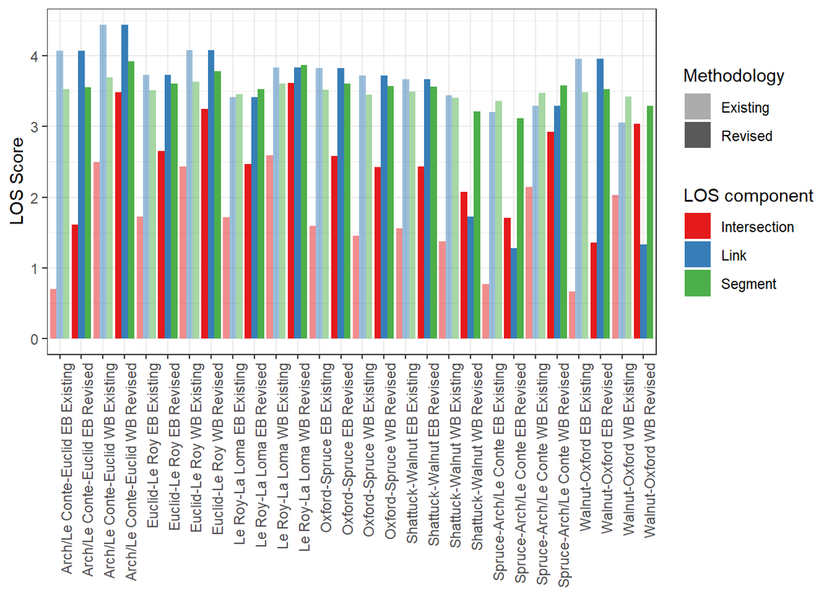

```r
library(ggplot2)
#Plot
ggplot(data = bike.scores, aes(x = id, y = value, fill = variable, alpha = method)) +
  geom_col(position = "dodge") +
  scale_fill_brewer("LOS component", palette = "Set1") +
  scale_alpha_discrete("Methodology", range = c(0.5,1)) +
  labs(x = NULL, y = "LOS Score") +
  theme_bw() +
  theme(axis.text.x = element_text(angle = 90, hjust = 1))
```

The resulting plot generally reflects what we saw in the table, but we can see that the segment LOS score is less sensitive to changes from intersections than from links. In another perspective we can compare the LOS from each methodology. Points above the diagonal line mean that the revised method yielded a higher (i.e., worse) LOS score, and points below the diagonal mean the revised method yielded a lower (i.e., better) LOS score.

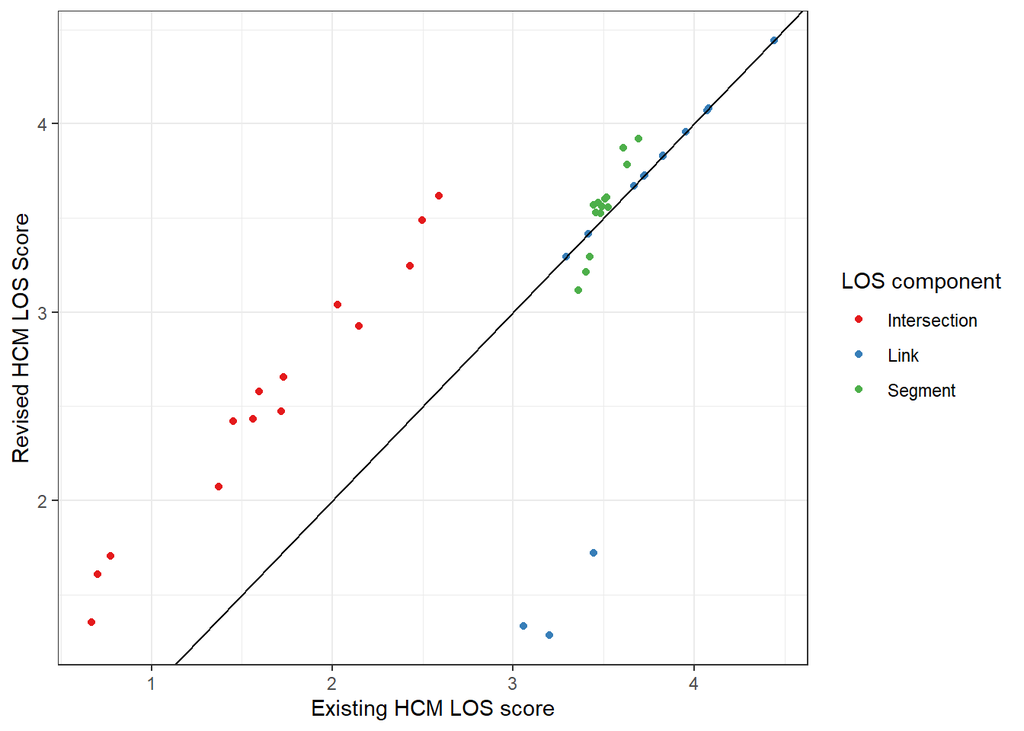

```r
ggplot(data = bike.scoresxy, aes(x = Existing, y = Revised, color = variable)) +
  geom_point() +
  geom_abline(slope = 1) +
  scale_color_brewer("LOS component", palette = "Set1") +
  labs(x = "Existing HCM LOS score", y = "Revised HCM LOS Score") +
  theme_bw()
```

## Existing versus revised HCM methodology

Getting a little bit more advanced, we can inspect how LOS score outputs vary while varying the input values. We can start by creating some starting default parameters. I start with the default template data, creating a list with every possible combination of speed and volume. Most parameters are constant except for average mid-segment speed $S_{85mj}$, and volume $v_v$, which will vary from 15 to 45 mph and 100 to 1200 vph in increments of 5 mph and 100 vph, respectively. The function “expand.grid” will then generate a data frame for all possible combinations of these sequences. I then do some house keeping, filling in some default values. Setting the right and left turn volume to be $\frac{1}{4}$ of total volume, proportionally. The right-on-red and permissive lefts are then further half of the left and right turn volumes.

```r
combos <- data.table(expand.grid(vol = seq(100, 1200, by = 100),
                                 spd = seq(15, 45, by = 5)))

#Just grabbing the first link and intersection from the data. Just as filler data
int <- split(dat$intersections, by = "int_id")[[1]]
link <- split(dat$links, by = c("link_id","link_dir"))[[1]]

combodat <- lapply(1:nrow(combos), function(x) {
  link$S_85mj <- combos[x, spd]
  int$v_v <- combos[x, vol]

  int[ , v_rt := v_v/4]
  int[ , v_lt := v_v/4]
  int[ , v_th := v_v/2]
  int[ , v_rtor := v_rt/2]
  int[ , v_ltperm := v_lt/2]
  int[ , int_id := x]
  return( list("intersection" = int, "link" = link) )
})
```

You don’t need to understand all of this, just know that I’m creating a big data table that has all possible combinations of speed and volume. Now we are going to actually calculate the LOS score using the data matrix we created. This goes through the data table twice, once using existing HCM and once using the revisions. There are a lot of combinations, this might take a few seconds to compute. Then, I again reshape the data into long form for plotting.

```r
#Calculate Intersection LOS
LOS.dat <- lapply(combodat, function(x) {
  data.table("v_v" = x[['intersection']]$v_v[1],
             "S_85mj" = x[['link']]$S_85mj[1],
             Revised = bike.I_int(x[['link']], x[['intersection']]),
             Existing = ogbike.I_int(x[['link']], x[['intersection']]))
  })
#combine list items into data table
LOS.dat <- rbindlist(LOS.dat)

#Melt into long form
LOS.dat <- melt(LOS.dat, c("v_v","S_85mj"))

#Score
LOS.dat$LOS <- sapply(LOS.dat$value, score2LOS)
```

Now we can plot the two and compare them. I use another package here called [ggpubr](https://cran.r-project.org/web/packages/ggpubr/index.html), which accompanies ggplot2 for presentation. In this case it let’s me plot them side by side. So what we see here is that the revisions account for traffic speed exposure while existing HCM methodology does not.

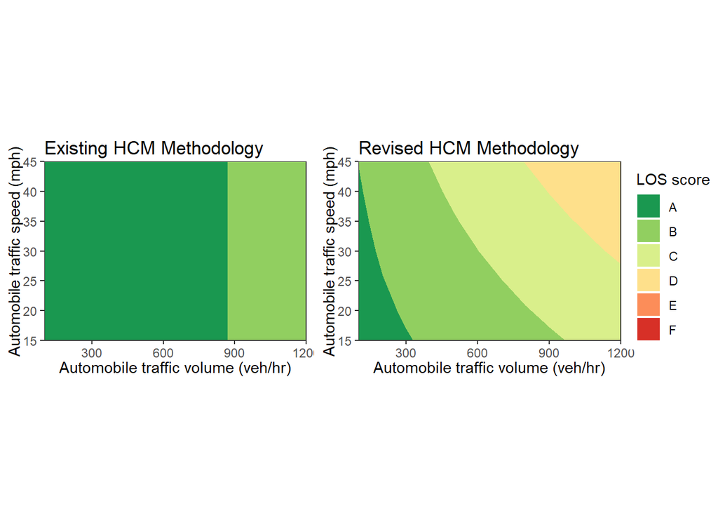

```r
plot.LOSint = lapply(c("Existing","Revised"), function(x) {
  ggplot(data = LOS.dat[variable == x, ], ) +
    #geom_tile(aes(x = v_v, y = S_85mj, fill = value)) +
    #scale_fill_distiller("LOS", palette = "RdYlGn", limits = range(LOS.int$value)) +
    geom_contour_filled(aes(x = v_v, y = S_85mj, z = value), breaks = c(-Inf,2.00,2.75,3.50,4.25,5.00,Inf)) +
    scale_fill_manual("LOS score", values = rev(RColorBrewer::brewer.pal(n = 6, name = "RdYlGn")),
                       labels = c("A","B","C","D","E","F"), drop = F) +
    scale_x_continuous("Automobile traffic volume (veh/hr)", expand = c(0,0)) +
    scale_y_continuous("Automobile traffic speed (mph)", expand = c(0,0)) +
    coord_fixed(ratio = 25) +
    theme_bw() + ggtitle(paste(x, "HCM Methodology")) +
    theme(text = element_text(family = "Times New Roman"), legend.position = "bottom")
})
names(plot.LOSint) <- c("rev","og")

library(ggpubr)
ggarrange(plotlist = plot.LOSint, ncol = 2, common.legend = T, legend = "right")
```

## Final thoughts

Okay now that we’ve gone through a short example, that should be enough to get going. More to come in future revisions. For more methodological details, see the bicycle revisions working paper titled [Improved Analysis Methodologies and Strategies for Complete Streets](https://github.com/nick-fournier/MMLOS/blob/master/docs/65A0723_Complete%20Streets%20Memo_DRAFT_4-30-2021.pdf) and for pedestrian revisions see the [collection of working papers](https://github.com/nick-fournier/MMLOS/blob/master/docs/Collection_of_working_papers.pdf) from NCHRP report 17-87.